# Practical Machine Learning Course Project

Matt R

April 25, 2015

### Load data

Load the libraries we’ll use, and set a seed so we can replicate results:

```r
library(caret)
library(RCurl)
```

```r
library(ggplot2)
options(warn=-1)
set.seed(98765432)
```

```r
pmltrainingraw <- getURL("https://d396qusza40orc.cloudfront.net/predmachlearn/pml-training.csv")
pmltestingraw <- getURL("https://d396qusza40orc.cloudfront.net/predmachlearn/pml-testing.csv")
```

### Exploratory Analysis

Some of the columns in the training dataset describe the observation rather than quantify it, so we remove them:

```r
pmltraining <- pmltraining[,-c(1:7)]
pmltesting <- pmltesting[,-c(1:7)]
```

Some of the columns were also primarily NA’s, or even all NA’s. Here we list those with greater than 95% na’s:

```r
nasizes <- data.frame()
for (i in 1:ncol(pmltraining)) {
    newrow <- data.frame(
        col = colnames(pmltraining)[i],
        nas = sum(is.na(pmltraining[colnames(pmltraining)[i]]))
        )
    nasizes <- rbind(nasizes, newrow)
}
nasizes$percent <- nasizes$nas / nrow(pmltraining)

high_nas <- as.character(nasizes[nasizes$percent > 0.95,]$col)
head(high_nas)
```

```
## [1] "kurtosis_roll_belt"   "kurtosis_picth_belt"  "kurtosis_yaw_belt"
## [4] "skewness_roll_belt"   "skewness_roll_belt.1" "skewness_yaw_belt"
```

We plotted the effect of each of those columns who had at least a few non-na values and determined that none had a noticable trend that could be influential in our model. Here’s an illustration of a one:

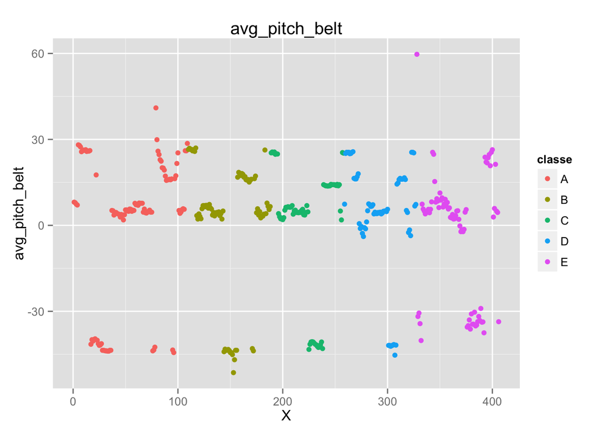

```r
col <- high_nas[20]
datatoplot <- pmltraining[!is.na(pmltraining[col]),]
datatoplot$X <- 1:nrow(datatoplot)
g <- ggplot(datatoplot, aes_string(x="X", y=col)) +
    geom_point(aes(color = classe)) +
    labs(title=col)
print(g)
```

So we decided to remove those columns.

```r
pmltraining <- pmltraining[,!(names(pmltraining) %in% high_nas)]
pmltesting <- pmltesting[,!(names(pmltesting) %in% high_nas)]
```

### Model Fitting

Now we’ll split the given training set into our own training and test sets for cross-validation purposes:

```r
inTrain <- createDataPartition(pmltraining$classe, p = 0.70, list=FALSE)
training <- pmltraining[inTrain,]
testing <- pmltraining[-inTrain,]
```

We’ll try a tree model and random forests model, and choose the one that works better. First, we train a tree model and output the in-sample confusion matrix to analyze performance:

```r
treefit <- train(classe ~ .,data=training, method="rpart")
treeinsampleprediction <- predict(treefit, newdata=training)
confusionMatrix(treeinsampleprediction, training$classe)
```

```
## Confusion Matrix and Statistics
##
##           Reference
## Prediction    A    B    C    D    E
##          A 3569 1132 1121  993  373
##          B   49  912   80  393  342
##          C  279  614 1195  866  691
##          D    0    0    0    0    0
##          E    9    0    0    0 1119
##
## Overall Statistics
##
##                Accuracy : 0.4946
##                  95% CI : (0.4863, 0.503)
##     No Information Rate : 0.2843
##     P-Value [Acc > NIR] : < 2.2e-16
##
##                   Kappa : 0.3393
##  Mcnemar's Test P-Value : NA
##
## Statistics by Class:
##
##                      Class: A Class: B Class: C Class: D Class: E
## Sensitivity            0.9137  0.34312  0.49875   0.0000  0.44317
## Specificity            0.6319  0.92201  0.78397   1.0000  0.99920
## Pos Pred Value         0.4965  0.51351  0.32785      NaN  0.99202
## Neg Pred Value         0.9485  0.85403  0.88099   0.8361  0.88849
## Prevalence             0.2843  0.19349  0.17442   0.1639  0.18381
## Detection Rate         0.2598  0.06639  0.08699   0.0000  0.08146
## Detection Prevalence   0.5233  0.12929  0.26534   0.0000  0.08211
## Balanced Accuracy      0.7728  0.63256  0.64136   0.5000  0.72118
```

```r
rffit <- train(classe ~ ., data=training,
               method = "rf",
               trControl = trainControl(method="cv", number=5))
rfinsampleprediction <- predict(rffit, newdata=training)
confusionMatrix(rfinsampleprediction, training$classe)
```

```
## Confusion Matrix and Statistics
##
##           Reference
## Prediction    A    B    C    D    E
##          A 3906    0    0    0    0
##          B    0 2658    0    0    0
##          C    0    0 2396    0    0
##          D    0    0    0 2252    0
##          E    0    0    0    0 2525
##
## Overall Statistics
##
##                Accuracy : 1
##                  95% CI : (0.9997, 1)
##     No Information Rate : 0.2843
##     P-Value [Acc > NIR] : < 2.2e-16
##
##                   Kappa : 1
##  Mcnemar's Test P-Value : NA
##
## Statistics by Class:
##
##                      Class: A Class: B Class: C Class: D Class: E
## Sensitivity            1.0000   1.0000   1.0000   1.0000   1.0000
## Specificity            1.0000   1.0000   1.0000   1.0000   1.0000
## Pos Pred Value         1.0000   1.0000   1.0000   1.0000   1.0000
## Neg Pred Value         1.0000   1.0000   1.0000   1.0000   1.0000
## Prevalence             0.2843   0.1935   0.1744   0.1639   0.1838
## Detection Rate         0.2843   0.1935   0.1744   0.1639   0.1838
## Detection Prevalence   0.2843   0.1935   0.1744   0.1639   0.1838
## Balanced Accuracy      1.0000   1.0000   1.0000   1.0000   1.0000
```

This model performs much better, accurately classifying all of training data. Let’s look at the cross-validation error:

```r
rffit
```

```
## Random Forest
##
## 13737 samples
##    52 predictor
##     5 classes: 'A', 'B', 'C', 'D', 'E'
##
## No pre-processing
## Resampling: Cross-Validated (5 fold)
##
## Summary of sample sizes: 10989, 10991, 10989, 10990, 10989
##
## Resampling results across tuning parameters:
##
##   mtry  Accuracy   Kappa      Accuracy SD  Kappa SD
##    2    0.9907551  0.9883040  0.001658615  0.002098425
##   27    0.9920656  0.9899628  0.002063475  0.002610656
##   52    0.9816551  0.9767938  0.002226139  0.002815789
##
## Accuracy was used to select the optimal model using  the largest value.
## The final value used for the model was mtry = 27.
```

The cross-validation out of bag error is 0.79344%, which we can use as an estimate of our out-of-sample error.

### Final Model Testing

We now run our model against the testing data we set aside, and check the confusion matrix to see how well it performed:

```r
testprediction <- predict(rffit, newdata=testing)
confusionMatrix(testprediction, testing$classe)
```

```
## Confusion Matrix and Statistics
##
##           Reference
## Prediction    A    B    C    D    E
##          A 1671   10    0    0    0
##          B    2 1129    2    2    0
##          C    0    0 1024   12    1
##          D    0    0    0  950    7
##          E    1    0    0    0 1074
##
## Overall Statistics
##
##                Accuracy : 0.9937
##                  95% CI : (0.9913, 0.9956)
##     No Information Rate : 0.2845
##     P-Value [Acc > NIR] : < 2.2e-16
##
##                   Kappa : 0.992
##  Mcnemar's Test P-Value : NA
##
## Statistics by Class:
##
##                      Class: A Class: B Class: C Class: D Class: E
## Sensitivity            0.9982   0.9912   0.9981   0.9855   0.9926
## Specificity            0.9976   0.9987   0.9973   0.9986   0.9998
## Pos Pred Value         0.9941   0.9947   0.9875   0.9927   0.9991
## Neg Pred Value         0.9993   0.9979   0.9996   0.9972   0.9983
## Prevalence             0.2845   0.1935   0.1743   0.1638   0.1839
## Detection Rate         0.2839   0.1918   0.1740   0.1614   0.1825
## Detection Prevalence   0.2856   0.1929   0.1762   0.1626   0.1827
## Balanced Accuracy      0.9979   0.9950   0.9977   0.9920   0.9962
```

We accurately classified 99.37% of the testing data, which is excellent performance, putting our out-of-sample error rate at 0.63%. This is an expected value considering our cross validation error rate was 0.79344%.

### Application to test cases

We create a list of predictions for the assignment’s test data and used the code given in the assignment to generate predictions files for the test data (intentionally not outputting here):

```r
assignmentprediction <- predict(rffit, newdata=pmltesting)
pml_write_files = function(x){
  n = length(x)
  for(i in 1:n){
    filename = paste0("problem_id_",i,".txt")
    write.table(x[i],file=filename,quote=FALSE,row.names=FALSE,col.names=FALSE)
  }
}
pml_write_files(assignmentprediction)
```